# Time Series Analysis of BabyECG data

Theo Lassale

**Introduction**

The data of this time series consists of 2048 electrocardiogram recorded values of a 66-day-old infant during a night from 21:17:59 to 06:27:18.

**Results**

We first plotted the time series :

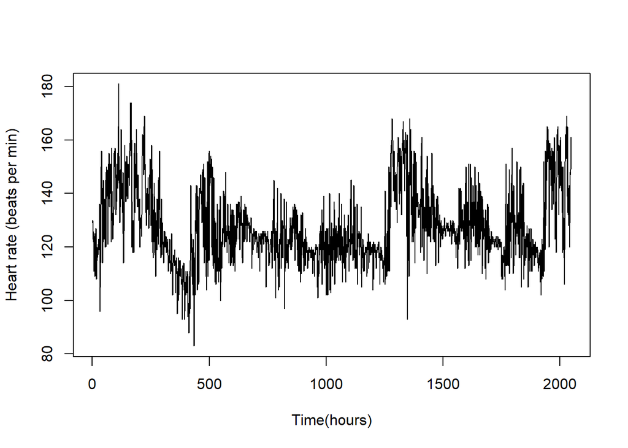

**Figure 1:** Electrocardiogram recording of a 66-day-old infant (BabyECG).

The data is not stationary by the presence of a not constant trend and of a changing variance over the time. This stationarity can be characterized by a strong correlation between the values of our series at different lags, which can be viewed on the ACF plot of our BabyECG series.

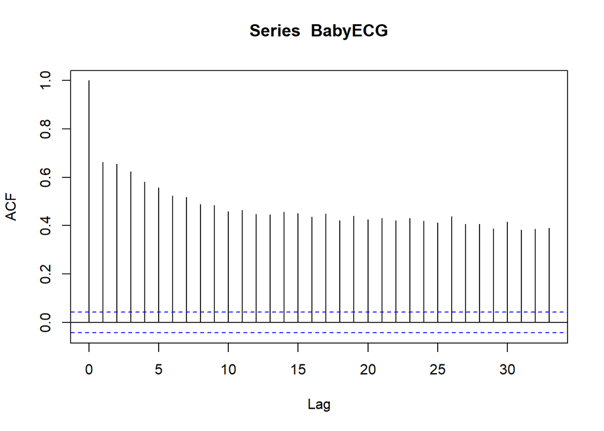

**Figure 1:** ACF of the BabyECG series.

This ACF plot shows a very low decay of the lags which stay all higher than the blue dotted line. This line gives the value beyond which the autocorrelations are (statistically) significantly different from zero and can be described as the blue significant threshold of our ACF plot. Therefore, all the lag values are significant and the corresponding variables are strongly positively correlated.  
We can now try to address the second-order non-stationary issue of the series by applying log and the square to it, then we plot these 2 transformations of the original series :

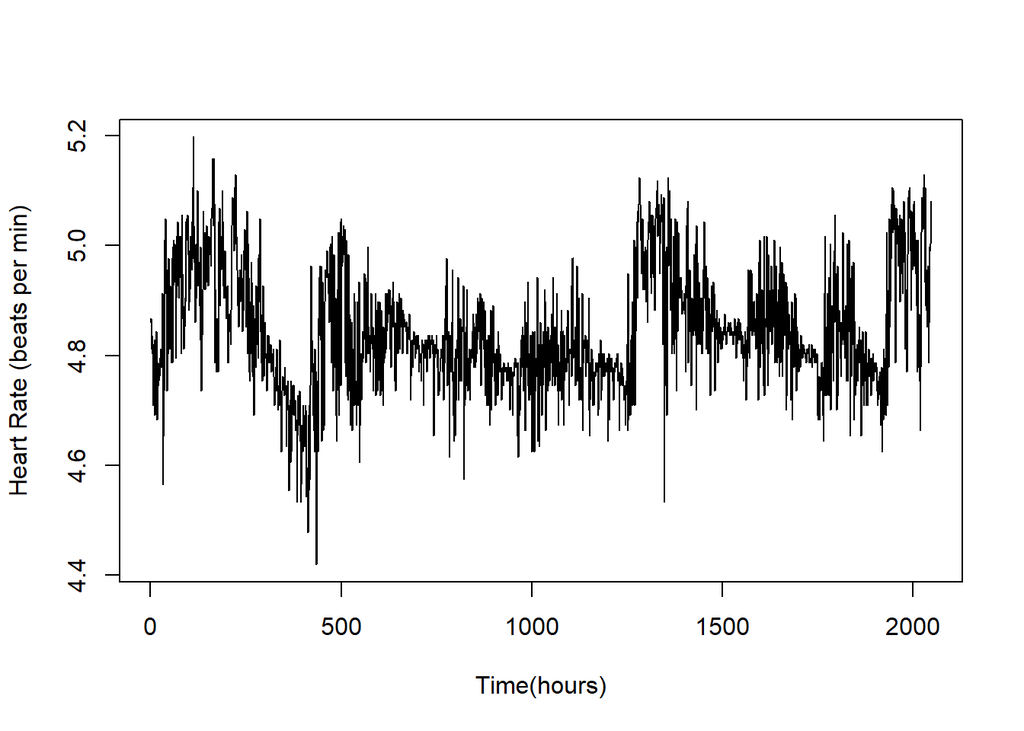

**Figure 2:** Logarithm of the BabyECG series.

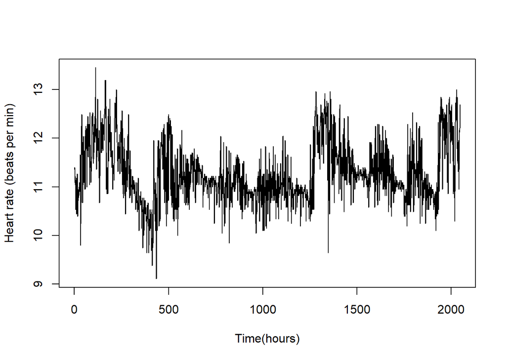

**Figure 3:** Square root of the BabyECG series.

We can see that these transformation procedures are not capable to stabilize the variance of the data as we can spot in these 2 plots the identical irregular variations seen in the standard series plot. We could therefore make us further of the Box-Jenkins method or of locally stationary processes for example, to yield second order stationarity but we won’t deal with the variance at the moment. Now, to address the trend component, we can take the first difference of our data then plotting it :

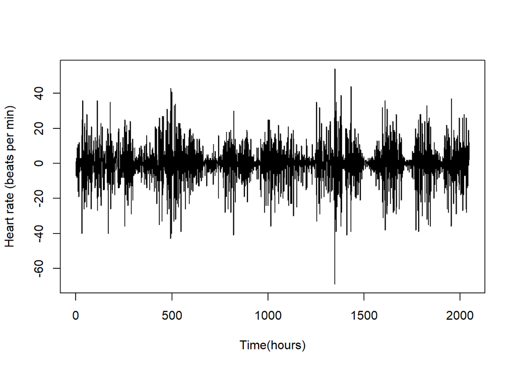

**Figure 4:** Differentiated BabyECG series.

We can see now that the trend of the data has been removed by this first difference yielding a constant mean through time and therefore a first-order stationary series.

Then, we plot the autocorrelation function as well as the partial autocorrelation of our differentiated series to investigate the potential drop of the correlation between the series value at current time and the values at different lags. Then, we can try to figure out the more appropriate model describing the (first-order) stationary behavior of our data.

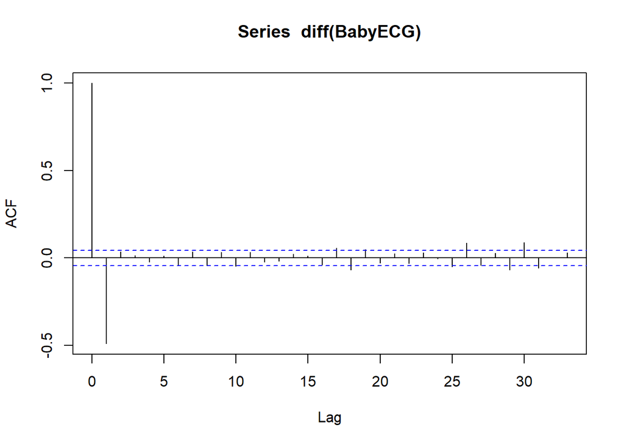

**Figure 5:** ACF of the differentiated BabyECG series.

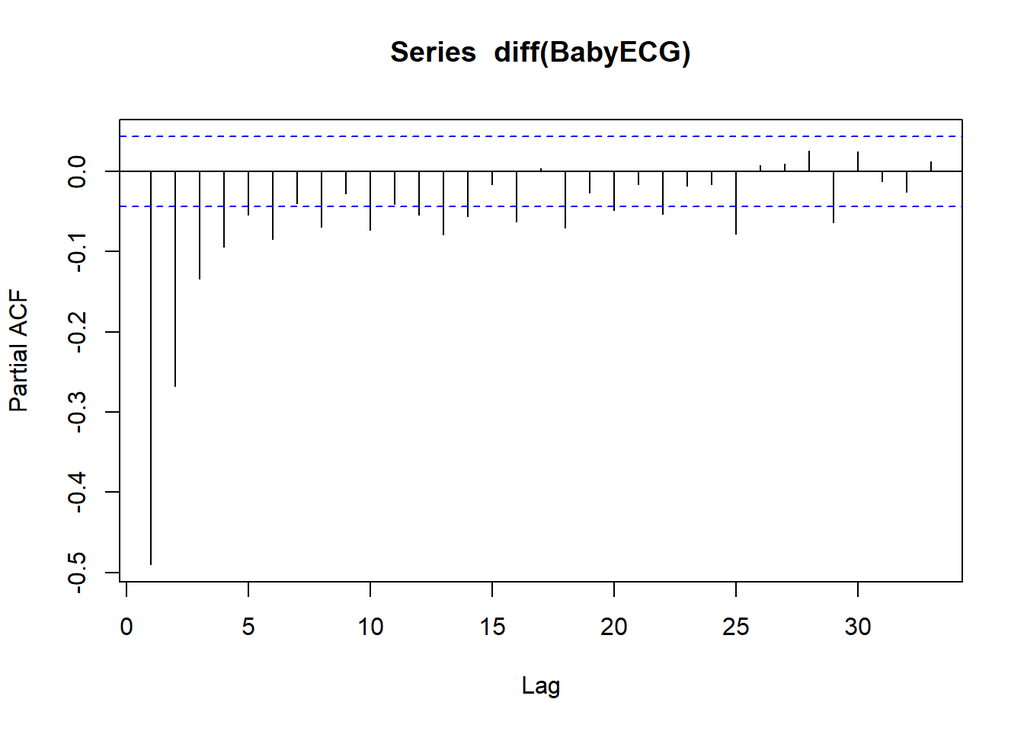

**Figure 6:** PACF of the differentiated BabyECG series.

Inspecting first the ACF , we can observe a significant decrease of the correlation between our time series at the present time with its lag values since the majority of the lag spikes fail below the blue significant threshold (except lags 1,17,18,26,29,30). Looking now at the PACF plot, we can note that the PACF decays asymptotically whereas ACF is cutting off at lag 2 . This would suggest the differentiated BabyECG series follows a moving average process of order 1 (MA(1)). So an initial candidate model for our initial BabyECG is an ARIMA(0,1,1). These 2 plots lead us also to think that a Moving-Average Process of order 2 (MA(2)) (i.e. ARIMA(0,1,2) model) could be as well efficient for our differentiated heart data. We can therefore fit these 2 potential models for our data.

```
##
## Call:
## arima(x = BabyECG, order = c(0, 1, 1))
##
## Coefficients:
##           ma1
##       -0.6917
## s.e.   0.0189
##
## sigma^2 estimated as 86.94:  log likelihood = -7474.99,  aic = 14953.98
```

```
## [1] 14965.23
```

```
##
## Call:
## arima(x = BabyECG, order = c(0, 1, 2))
##
## Coefficients:
##           ma1     ma2
##       -0.6920  0.0005
## s.e.   0.0213  0.0251
##
## sigma^2 estimated as 86.94:  log likelihood = -7474.99,  aic = 14955.98
```

```
## [1] 14972.85
```

The fitted ARIMA(0,1,1) model has lower criteria values (AIC and BIC) than the ARIMA(0,1,2) one. We can test as well for significance by looking at the p-values for the parameters of our both ARIMA models. The results of significance for ARIMA(0,1,1) and ARIMA(0,1,2) are shown below respectively.

```
##
## z test of coefficients:
##
##     Estimate Std. Error z value  Pr(>|z|)
## ma1 -0.69173    0.01885 -36.696 < 2.2e-16 ***
## ---
## Signif. codes:  0 '***' 0.001 '**' 0.01 '*' 0.05 '.' 0.1 ' ' 1
```

```
##
## z test of coefficients:
##
##        Estimate  Std. Error  z value Pr(>|z|)
## ma1 -0.69198784  0.02133855 -32.4290   <2e-16 ***
## ma2  0.00047459  0.02510144   0.0189   0.9849
## ---
## Signif. codes:  0 '***' 0.001 '**' 0.01 '*' 0.05 '.' 0.1 ' ' 1
```

The p-value for the first parameter corresponding to the random error at lag 1 is extremely small for our both models, which means that the lag 1 error is significant for our two ARIMA models. Conversely, the p-value for the second parameter referring to the random error at lag 2 from our ARIMA(0,1,2) model is not significant at all, given its large value. We infer that the lag 2 error does not really make any contribution to the heart data modeling. The ARIMA(0,1,1) would be then a better fit for our heart data. We can try now to implement our best ARIMA model with the best orders by using the automated process.

```
## Series: BabyECG
## ARIMA(3,1,1)
##
## Coefficients:
##          ar1     ar2     ar3      ma1
##       0.2217  0.2052  0.1222  -0.9373
## s.e.  0.0253  0.0245  0.0238   0.0117
##
## sigma^2 = 84.6:  log likelihood = -7445.3
## AIC=14900.59   AICc=14900.62   BIC=14928.71
```

An ARIMA(3,1,1) is returned as the best fit for our intial BabyECG data with the lowest criteria values for AIC and BiC among the two models fitted previously. We can check again for significance but now with this ARIMA(3,1,1) model.

```
##
## z test of coefficients:
##
##      Estimate Std. Error  z value  Pr(>|z|)
## ar1  0.221678   0.025307   8.7595 < 2.2e-16 ***
## ar2  0.205217   0.024492   8.3790 < 2.2e-16 ***
## ar3  0.122178   0.023810   5.1314 2.876e-07 ***
## ma1 -0.937312   0.011726 -79.9350 < 2.2e-16 ***
## ---
## Signif. codes:  0 '***' 0.001 '**' 0.01 '*' 0.05 '.' 0.1 ' ' 1
```

It appears that for each coefficient of the model, each corresponding p-value is very small (< 0.05), we can deduce then that the three lag autoregressive values and the one lag random error are statistically significant for this model. However, before drawing any modeling conclusion, as part of the diagnostic, we need to check the residuals of this ARIMA model as if it fits well our heart data then the standardized residuals should behave as an independent and identically sequence of variables with mean zero and constant variance. We can therefore plot them to investigate the behavior of their mean and of their variance over the time, in Figure 7. Their ACF and PACF are as well shown in respectively Figure 8 and 9 to examine any departure from their uncorrelation assumption.

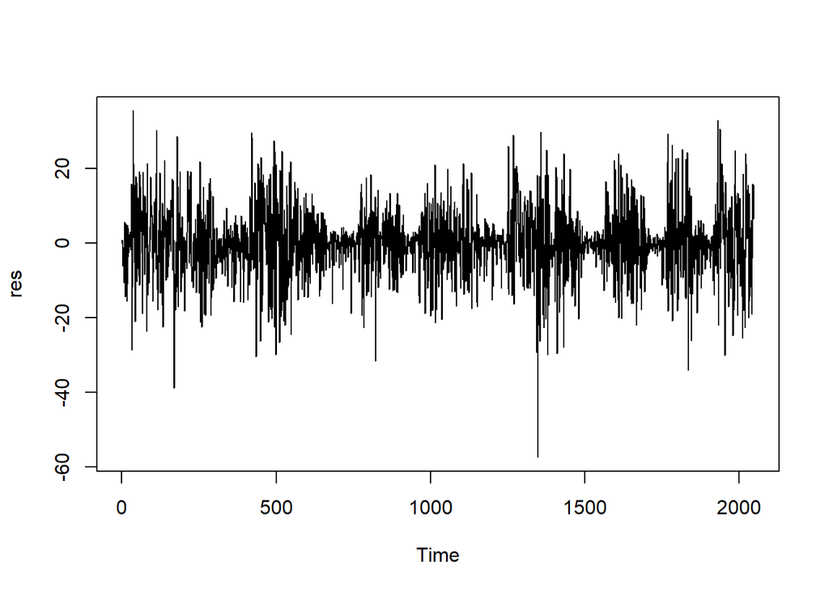

**Figure 7:** Residual Plot for the ARIMA(3,1,1) model.

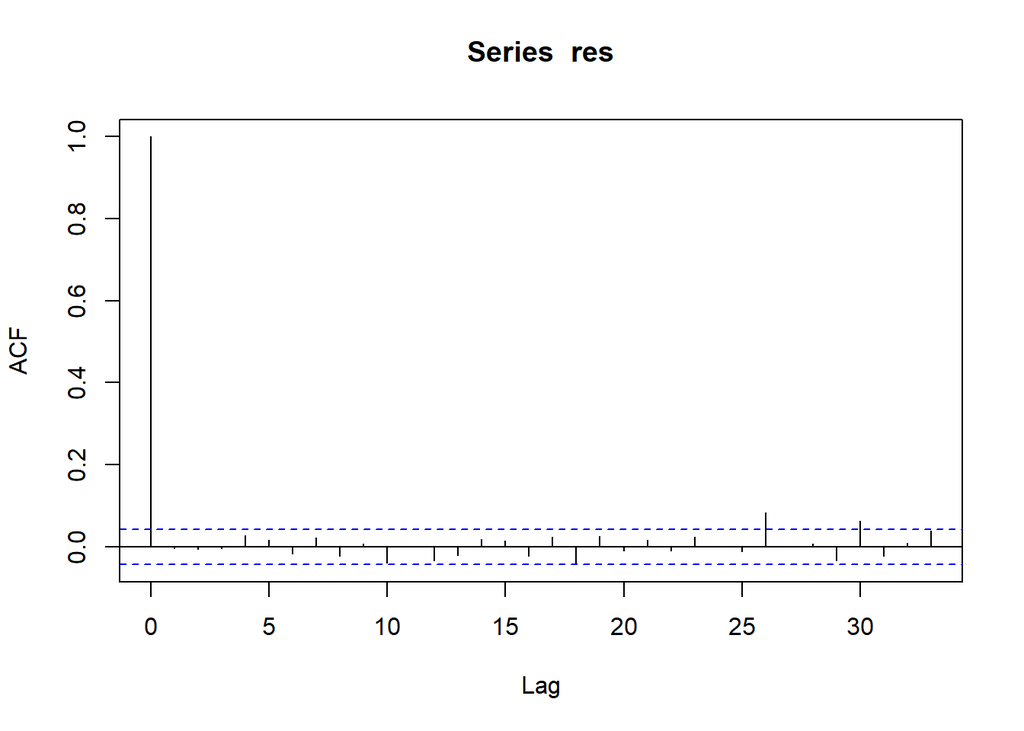

**Figure 8:** ACF of the residuals from our ARIMA(3,1,1) model applied to the BabyECG data.

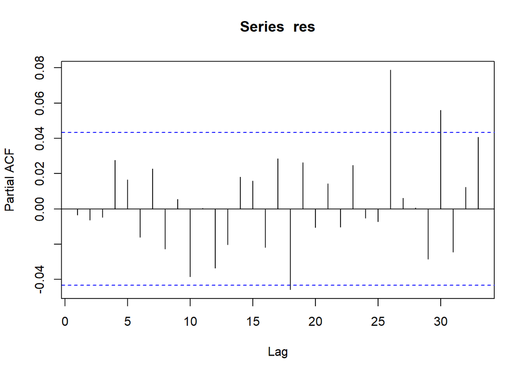

**Figure 9:** PACF of the residuals from our ARIMA(3,1,1) model applied to the BabyECG data.

The time plot of the residuals reflects a constant mean of around 0 over the time. On their ACF and PACF plots, except at 3 lags (18,26 and 30), there is no apparent correlation between our lag values, as the corresponding spikes do not exceed the significant threshold. We have now therefore the evidence of the non-correlated mean structure of our residuals (confirming their time plot). In addition, Ljung-Box test also provides a different way to double check the model. This test is a test of autocorrelation in which it verifies whether the autocorrelations of the residuals are different from 0 or not. In other words, if the result rejects the null hypothesis, this means there is serial dependence between the residuals, otherwise we have a numerical evidence of independently distributed residuals.

[output not shown]

The output shows that the p-value is relatively small (< 0.05), we have therefore enough evidence to reject the null hypothesis of independence of our residuals. This result can lead us to assume the existence of a potential higher order dependence of the residuals . Moreover, if we take a look at their time plot, we can clearly see periods of swings interspersed with periods of relative calm describing in fact the irregular pattern of the variance of these residuals. Thus, it suggests graphically that this further dependence of the residuals is related to their variance, corresponding to a second-order dependence. We can now extend our analysis of the residual variance by squaring these residuals and then looking at their time plot and ACF/PACF plots.

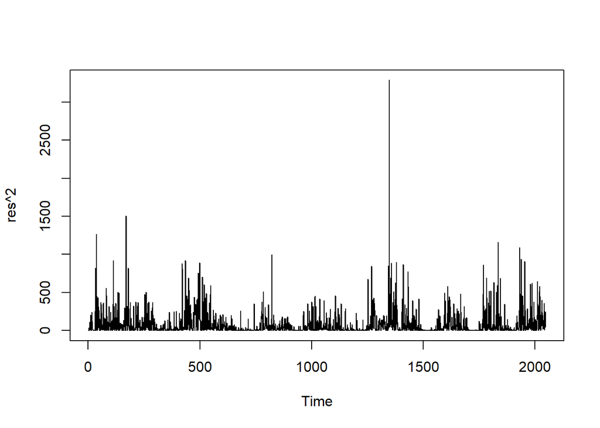

**Figure 10:** Squared residual Plot for the ARIMA(3,1,1) model.

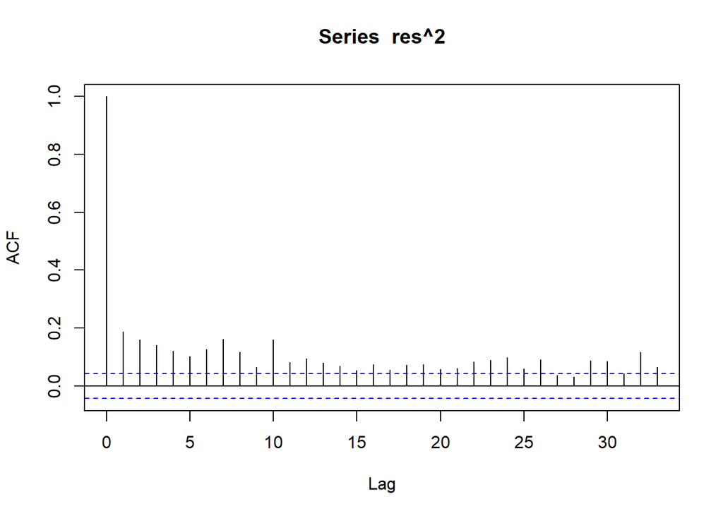

**Figure 10:** ACF of the squared residuals from our ARIMA(3,1,1) model applied to the BabyECG data.

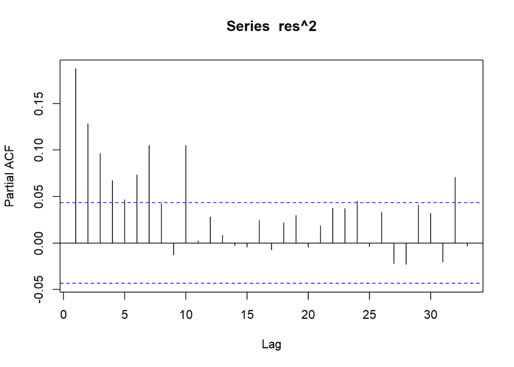

**Figure 11:** PACF of the squared residuals from our ARIMA(3,1,1) model applied to the BabyECG data.

From these results, it is trivial now to infer a correlated variance structure of our residuals given the heteroscedasticity in the ARIMA residuals (namely known as ARCH effects) as clearly multiple spikes in the both ACF and PACF of the squared residuals are significant and clusters of points with difference of variance (in time) are shown in the squared residuals plot. ARIMA seems thus not being able to model this dynamic variance of the residuals and to that end we should make use of the class of non-linear time series models, namely the GARCH models. These models will use values of the past squared residuals and of the past residual variances to model the residual variance at current time. In the GARCH notation, the first subscript (p) refers to the number of lag variances (GARCH part) and the second subscript (q) refers to the number of lag squared residual errors (ARCH part). We could look again at the ACF and PACF of the squared residuals but in this case now to determine appropriate values for the orders p and q of potential GARCH model(s). Inspecting these 2 plots (just above), it appears that the ACF tails off and the PACF cuts off after lag 10. This would suggest our residuals follow a GARCH(0,10) model or equivalently an ARCH(10) one. Therefore, we can try first to fit this model.

```
##
## Call:
## garch(x = res, order = c(0, 10), trace = F)
##
## Model:
## GARCH(0,10)
##
## Residuals:
##      Min       1Q   Median       3Q      Max
## -4.44467 -0.51143  0.03646  0.47223  3.53141
##
## Coefficient(s):
##      Estimate  Std. Error  t value Pr(>|t|)
## a0  4.221e+01   2.999e+00   14.076  < 2e-16 ***
## a1  1.582e-01   2.627e-02    6.022 1.72e-09 ***
## a2  6.145e-02   2.688e-02    2.286   0.0222 *
## a3  6.678e-02   1.688e-02    3.956 7.63e-05 ***
## a4  5.017e-02   1.775e-02    2.827   0.0047 **
## a5  3.205e-02   2.463e-02    1.301   0.1932
## a6  3.787e-02   2.323e-02    1.630   0.1030
## a7  5.455e-02   2.657e-02    2.053   0.0400 *
## a8  3.760e-02   2.493e-02    1.509   0.1314
## a9  7.451e-13   2.404e-02    0.000   1.0000
## a10 4.353e-02   2.131e-02    2.043   0.0411 *
## ---
## Signif. codes:  0 '***' 0.001 '**' 0.01 '*' 0.05 '.' 0.1 ' ' 1
##
## Diagnostic Tests:
##  Jarque Bera Test
##
## data:  Residuals
## X-squared = 144.58, df = 2, p-value < 2.2e-16
##
##
##  Box-Ljung test
##
## data:  Squared.Residuals
## X-squared = 7.7687, df = 1, p-value = 0.005316
```

From the R output, the p-values for the 5th, 6th, 8th and 9th parameters are reasonably large (> 0.05), indicating that the corresponding lag squared residuals do not significantly affects our residual variance. Additionally, the p-value of Box-Ljung Test is really small (< 0.05) and thus we need to reject the null hypothesis of uncorrelation of our ARIMA squared residuals (i.e of second-order independence of our residuals). This model is consequently a poor fit for our residual variance. We can try now to fit a restricted model by removing lags from 5 up to 10 to boil down a GARCH(0,4) model (i.e an ARCH(0,4) model ) and then compare this fit with the previous one.

```
##
## Call:
## garch(x = res, order = c(0, 4), trace = F)
##
## Model:
## GARCH(0,4)
##
## Residuals:
##      Min       1Q   Median       3Q      Max
## -4.24215 -0.54983  0.03716  0.49553  4.40473
##
## Coefficient(s):
##     Estimate  Std. Error  t value Pr(>|t|)
## a0  25.34851     1.35913   18.651  < 2e-16 ***
## a1   0.31977     0.03293    9.710  < 2e-16 ***
## a2   0.13651     0.02725    5.011 5.43e-07 ***
## a3   0.18927     0.02294    8.251 2.22e-16 ***
## a4   0.17860     0.02554    6.993 2.69e-12 ***
## ---
## Signif. codes:  0 '***' 0.001 '**' 0.01 '*' 0.05 '.' 0.1 ' ' 1
##
## Diagnostic Tests:
##  Jarque Bera Test
##
## data:  Residuals
## X-squared = 207.94, df = 2, p-value < 2.2e-16
##
##
##  Box-Ljung test
##
## data:  Squared.Residuals
## X-squared = 0.2462, df = 1, p-value = 0.6198
```

All the p-values are very small (< 0.05) and thus our 4 lag squared residuals have a significant impact on our residual variance. Moreover, the p-value returned by the Box-Ljung test is now really large (> 0.05), indicating now a relatively strong uncorrelation of our squared residuals.

Before drawing any conclusion, we should keep an eye as well on the ACF/PACF plots of the squared residuals extracted from our GARCH(0,4) model to examine any departure of our last Ljung-Box Test results.

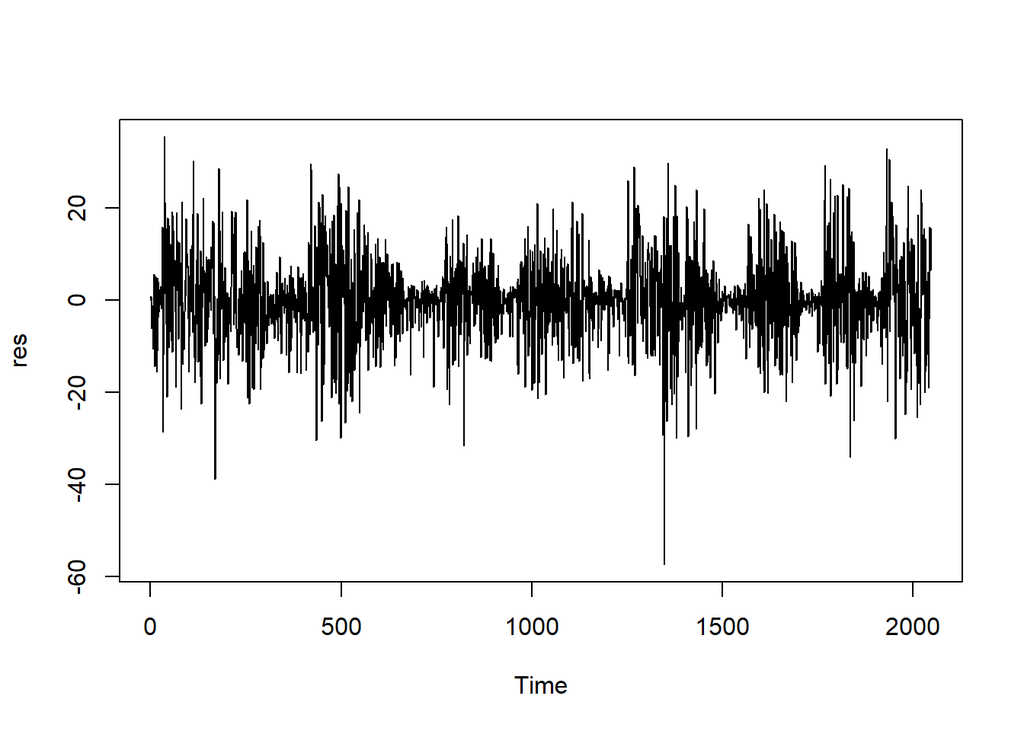

**Figure 12 :** Time Plot of the ARIMA(3,1,1) residuals.

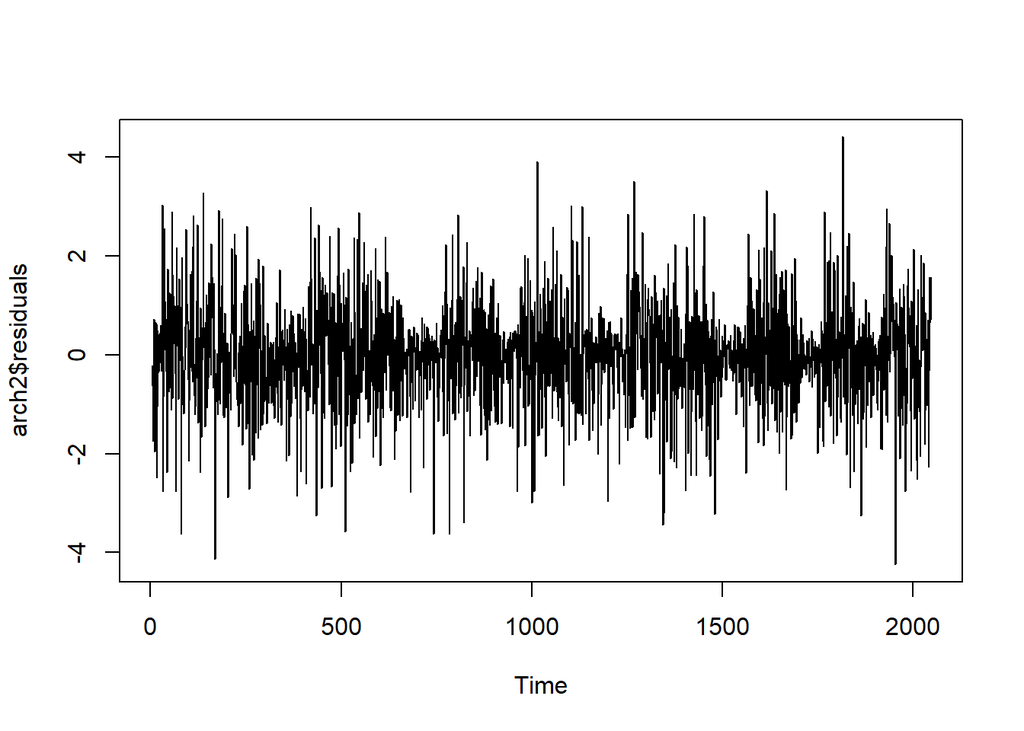

**Figure 13 :** Time Plot of the GARCH(0,4) residuals.

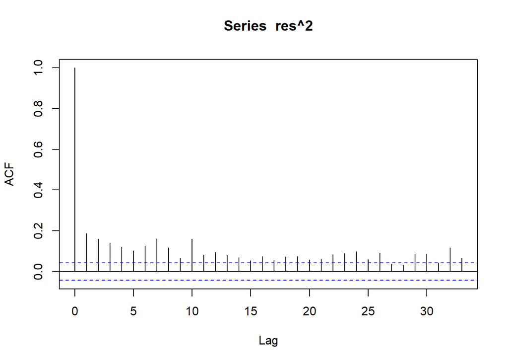

**Figure 14 :** ACF plot of the ARIMA(3,1,1) squared residuals.

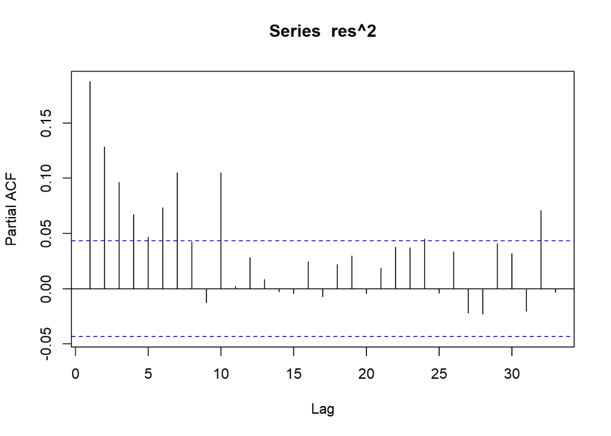

**Figure 15 :** PACF plot of the ARIMA(3,1,1) squared residuals.

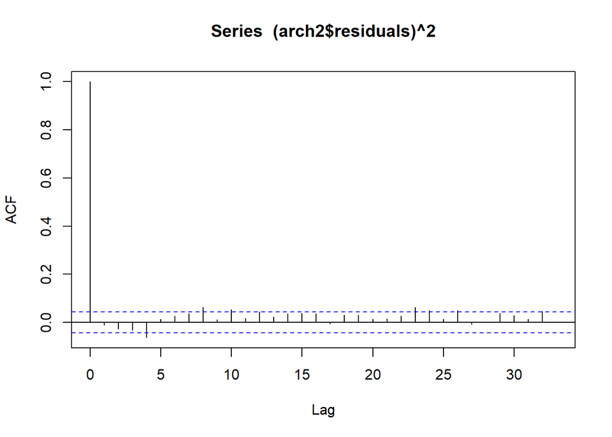

**Figure 16 :** ACF plot of the GARCH(0,4) squared residuals.

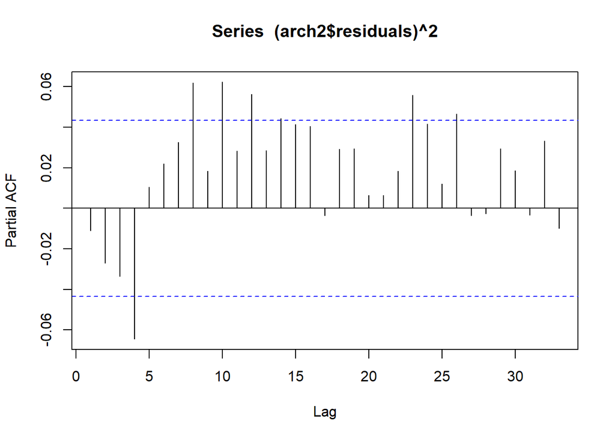

**Figure 17 :** PACF plot of the GARCH(0,4) squared residuals.

Back now to the differentiated BabyECG data showing a constant mean with though a non-constant second-order structure through time. By examining closely our process, we can notice though that its variance seems to vary slowly over time with very short stretches of time where the data appears to have a relatively (second-order) stationary behaviour, which suggests to assume the locally stationary character of the differentiated heart series. We can then try to model this typical series by leading a time-scale modeling approach which replaces the set of of Fourier functions {exp(iωt)},ω ∈ (−π,π)} by a set of discrete non-decimated wavelets {ψj,k(t)}j,k and called locally stationary wavelet (LSW) processes. Informally, these processes are built out of wavelets with random amplitudes at different scale j and time location z ∈ (0, 1) (z is actually a rescaled time). Moreover, to determine how the variance is distributed across scale j and location z, we define the evolutionary wavelet spectrum (ews) as the “summary statistic” of its corresponding LWS. This spectrum equals the square of the amplitude coefficients of the wavelets at scale j and time z. For example, a large value of this spectrum at scale j and time z would indicate that there is a large amount of oscillatory power operating at scale j around location z. The evolutionary wavelet spectrum may be estimated by a raw wavelet periodogram which is defined as the square of the empirical non-decimated wavelet coefficients of the series at time z. However, this (raw) periodogram needs to be smoothed as a function of location for each scale j (to obtain consistency) and then should be corrected by a bias correction in order to provide an unbiased spectrum estimator. The figure below shows a smoothed corrected wavelet periodogram for the differentiated ECG data.

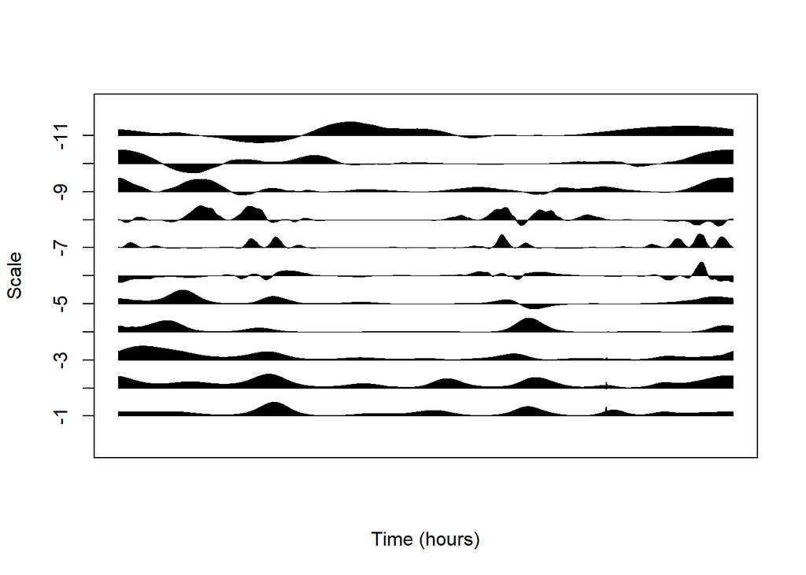

**Figure 18 :** Corrected smoothed wavelet periodogram of the differenced BabyECG data.

This periodogram shows us that the non-decimated wavelets at each scale j (from j=-1 to 11) do have time-varying amplitude over the whole night, which is a spectral evidence of the second-order non stationarity across scale and time of our differentiated heart data. However, we can find within each scale some periods of time where consecutive wavelets have a pretty constant amplitude corresponding to (almost) constant squared empirical coefficients, which can be referred to the local stationarity of the process.

We could now apply this time-scale spectral approach on the ARIMA residuals to obtain an oscillatory view of the time-changing variance of these residuals (spotted from their time plot) at different scales.

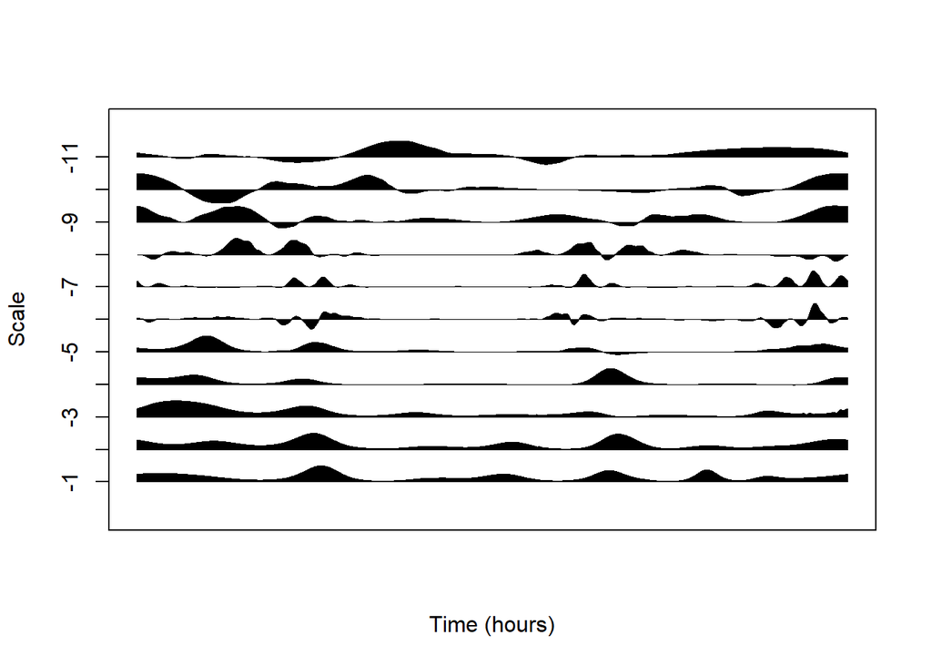

**Figure 19 :** Corrected smoothed wavelet periodogram of the ARIMA residuals.

This spectrum is an evidence of the second-order dependence of the residuals, with irregular variations between the amplitudes of the non-decimated wavelet transforms of the values of the residual series at each scale. Again, we can spot some moments of local stationarity over stretches of (rescaled) time where the oscillatory power of consecutive wavelet signals is similar. We can lead now the same approach but for the residuals extracted for our GARCH model. Below is the smoothed corrected wavelet periodogram for our GARCH residuals.

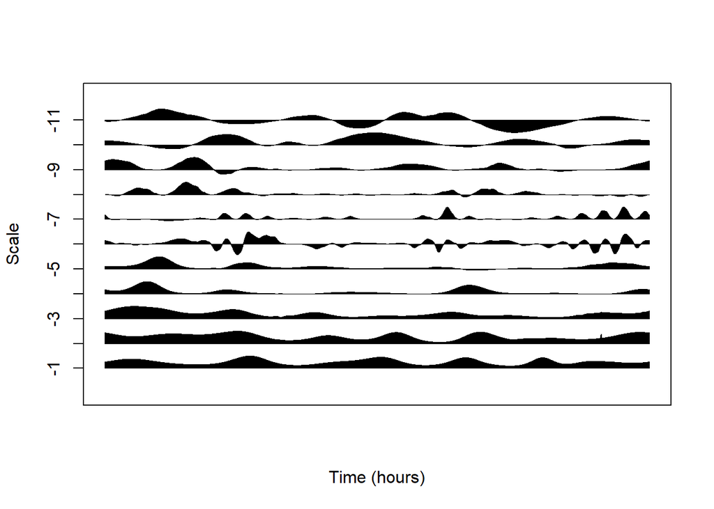

**Figure 20 :** Corrected smoothed wavelet periodogram of the GARCH residuals.

It appears that there are less irregular variations across the different scales and time , especially for finer scales such as from j=-3 to j=-1 where the oscillator power looks pretty constant over time z, corresponding to (almost) non-varying empirical non-decimated wavelet coefficients across these scales and time z. Therefore, we have now the spectral evidence of a more stable variance of our residuals over time (in addition to the time-domain evidence earlier), stabilized actually by our GARCH(0,4) model.

The wavelet spectrum can now be used to perform a numerical test of the second-order stationarity for the differentiated heart data as well as for the residual series. This test is based on the computation of the Haar wavelet coefficients of each scale at each time point of the evolutionary wavelet spectrum estimate for our underlying series. It is actually a multiple hypothesis test assessing whether any of the Haar coefficients are large enough to reject the null hypothesis of stationarity. The results of this test on the differentiated series are shown below.

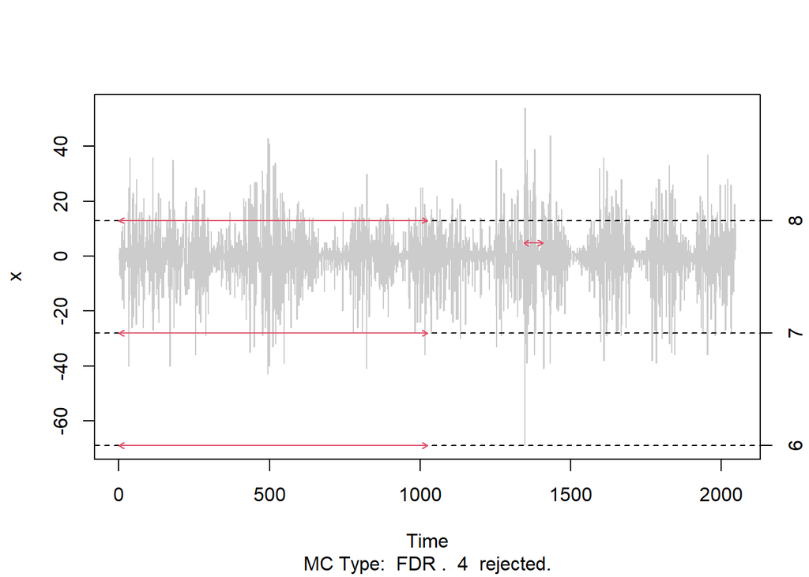

**Figure 21:** Time plot of the differenced BabyECG series {Yt} with non-stationarity indicators.

We can notice that 4 Haar wavelets coefficients were deemed significant by our test of stationarity according to the False Discovery Rate (FDR) procedure , leading to 4 rejections. These 4 non-stationary indicators are thus the evidence of the second order non-stationarity of the differentiated heart data. We can now apply this same approach on our residuals to examine any departure of the null hypothesis of their second-order stationarity.

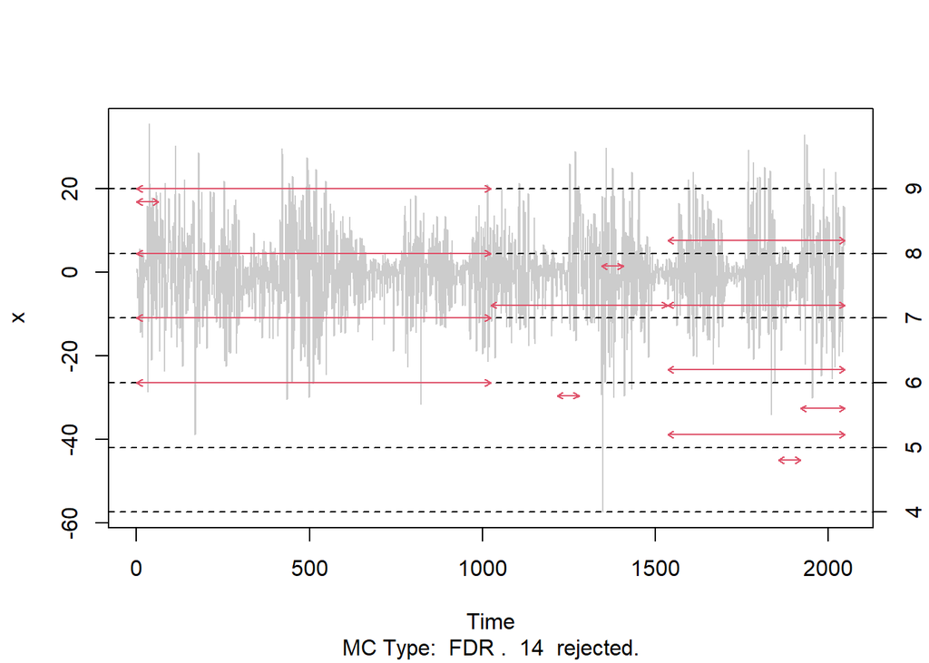

**Figure 22:** Time plot of the ARIMA residual series {εt} with non-stationarity indicators.

This time, 14 Haar wavelets coefficients got rejected by the False Discovery Rate (FDR) procedure, which suggests the strong (second-order) dependency of the ARIMA residuals. Furthermore, we can note that these residuals exhibit a higher degree of non-stationarity than the differentiated data (14 against 4 rejections). We can then try to test the (second-order) stationarity of the GARCH residuals to inspect numerically whether our GARCH(0,4) model removed some second-order dependency of our residuals.

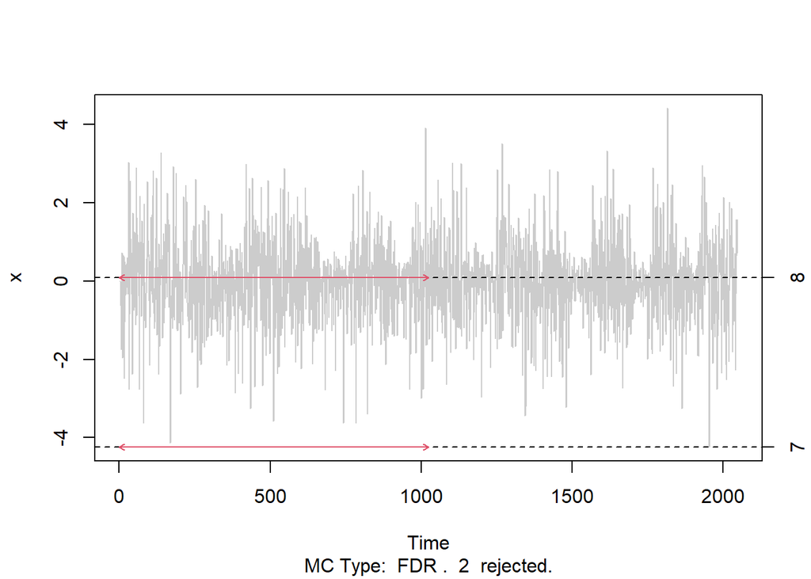

**Figure 23**: Time plot of the ARIMA+GARCH residual series {εt} with non-stationarity indicators.

**APPENDIX 1: R commands and output for the BabyECG data**

`> install.packages("wavethresh",repos = "http://cran.us.r-project.org")`  
`> library(wavethresh)`  
`> data(BabyECG)`  
`> plot(BabyECG, type = "l", xlab = "Time(hours)", ylab = "Heart rate (beats per min)")`

`> acf(BabyECG)`

`> plot(log(BabyECG), type = "l", xlab= "Time(hours)", ylab = "Heart Rate (beats per min)")`

`> plot(sqrt(BabyECG), type = "l", xlab = "Time(hours)", ylab = "Heart rate (beats per min)")`

`> plot(diff(BabyECG), type = "l", xlab = "Time(hours)", ylab = "Heart rate (beats per min)")`

`> plot(acf(diff(BabyECG)))`  
`> plot(pacf(diff(BabyECG)))`

`> fit <- arima(BabyECG, order = c(0,1,1))`  
`> fit`  
`> BIC(fit)`

`> fit1 <- arima(BabyECG, order = c(0,1,2))`  
`> fit1`  
`> BIC(fit1)`

`> coeftest(fit)`  
`> coeftest(fit1)`

`> install.packages("forecast",repos = "http://cran.us.r-project.org" )`  
`> library(forecast)`

`> fit2 <- auto.arima(BabyECG)`  
`> fit2`  
`> coeftest(fit2)`

`> res <- fit2$residuals`  
`> plot(res)`  
`> acf(res)`  
`> pacf(res)`

`> Box.test (res, lag = 20, type = "Ljung")`

`> plot(res^2)`  
`> acf(res^2)`  
`> pacf(res^2)`

`> library(tseries)`

`> arch1=garch(res,order=c(0,10),trace=F)`  
`> summary(arch1)`

`> arch2=garch(res,order=c(0,4),trace=F)`  
`> summary(arch2)`

`> plot(res)`  
`> plot(arch2$residuals)`

`> acf(res^2)`  
`> pacf(res^2)`

`> acf((arch2$residuals)^2,na.action=na.contiguous)`  
`> pacf((arch2$residuals)^2,na.action=na.contiguous)`

`> sttm <- 21+(17+59/60)/60`  
`> tchar <- c("22", "23", "00", "01", "02", "03", "04", "05","06")`  
`> tm2 <- c(22,23, 24, 25, 26, 27, 28, 29, 30)`  
`> m2 <- tm2 - sttm`  
`> tm2s <- tm2*60*60`  
`> tm2u <- tm2s/16`

`> dBabyECG <- diff(c(BabyECG[2], BabyECG))`  
`> library(locits)`  
`> spec <- ewspec(dBabyECG,smooth.levels=4:10,smooth.policy="universal",smooth.transform=log,smooth.inverse=exp)$S`  
`> plot(spec, main="",sub="",ylabchars=-(1:11),scaling="by.level", ylab="Scale",xlab="Time (hours)",xlabvals=tm2u, xlabchars=tchar)`

`> spec <- ewspec(res,smooth.levels=4:10,smooth.policy="universal",smooth.transform=log,smooth.inverse=exp)$S`  
`> plot(spec, main="", sub="", ylabchars=-(1:11),scaling="by.level",ylab="Scale",xlab="Time (hours)",xlabvals=tm2u, xlabchars=tchar)`

`> length(arch2$residuals)<-2^ceiling(log(length(arch2$residuals),2))`  
`> arch2$residuals[is.na(arch2$residuals)]<-0`  
`> spec <- ewspec(arch2$residuals,smooth.levels=4:10,smooth.policy="universal",smooth.transform=log,smooth.inverse=exp)$S`  
`> plot(spec, main="", sub="", ylabchars=-(1:11),scaling="by.level", ylab="Scale",xlab="Time (hours)",xlabvals=tm2u, xlabchars=tchar)`

`> a <- hwtos2(dBabyECG, alpha = 0.05, filter.number = 1, family = "DaubExPhase", lowlev = 3, WTscale = NULL, maxSD = NULL, verbose = FALSE, silent = FALSE, UseCForVarip2 = TRUE, OPLENGTH = 1e+05)`  
`> plot(a)`

`> b <- hwtos2(res, alpha = 0.05, filter.number = 1, family = "DaubExPhase", lowlev = 3, WTscale = NULL, maxSD = NULL, verbose = FALSE, silent = FALSE, UseCForVarip2 = TRUE, OPLENGTH = 1e+05)`  
`> plot(b)`

`> c <- hwtos2(arch2$residuals, alpha = 0.05, filter.number = 1, family = "DaubExPhase", lowlev = 3, WTscale = NULL, maxSD = NULL, verbose = FALSE, silent = FALSE, UseCForVarip2 = TRUE, OPLENGTH = 1e+05)`  
`> plot(c)`